# Frito-Lay Data Analysis

Jasmine O’Neal

12/1/2021

# Introduction:

### The CEO and CFO of Frito-Lay have tasked consultant Jasmine O’Neal from DDSAnalytics to get a better understanding of DDSAnalytics application of data science driven talent management capabilities. They’ve asked that analysis be performed using existing employee data before signing on to leverage those capabilities for future use.

### Provided relevant employee data to aid analysis.

### Frito-Lay is interested in understanding factors that contribute to turnover and any other interesting insights that should be highlighted in understanding the employee makeup of Frito-Lay.

1. Determine the top three factors that contribute to turnover
2. Classify likelihood of turnover based on key factors
3. Find other relevant insights from analysis

### Additional questions can be directed towards jasmineo@smu.edu

# Tools:

### This analysis uses R to ingest the CaseStudy2-data.csv dataset to answer the high-level questions outlined above. Also leveraged were ggplot2 visualization capabilities for charting and exploring the data.

### Statistical methods were also used, such as KNN classification, Naive Bayes, and Linear Regression to identify likelihood of turnover based on different factors.

# Purpose of the following Code:

### Given the CaseStudy2-data.csv dataset from the CEO and CFO of Frito-Lay, and tasked to understand the top three factors that lead to turnover.

### The following code will display those top three factors, classifcation of turnover, and other insights derived from analysis.

### Before understanding the top factors that lead to turnover, need to see what the turnover breakdown is at Frito-Lay currently.

# Breakdown of Employee Attrition at Frito-Lay:

### The dataset consists of 870 observations in which 84% of employees stayed verses 16% that left. This indicates that Frito-Lay doesn’t experience much attrition, however need to explore factors that do lead to attrition.

*Please note, the attrition imbalance from the bar charts below. The analysis to identify the top three factors of attrition will be performed using the dataset as-is. However, when classifying attrition using certain modeling techniques the dataset will be manipulated in order to balance the data for accurate predictions.

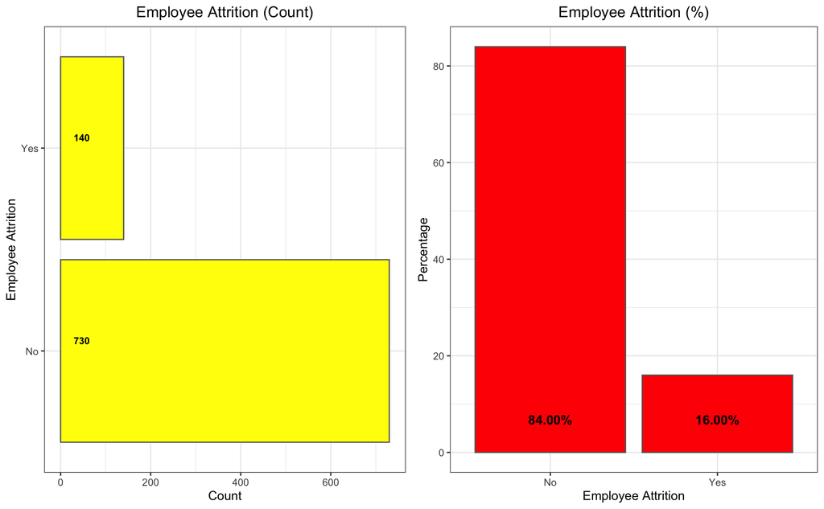

```r
# Read CaseStudy2-data csv
HR = read.csv('CaseStudy2-data.csv', header = TRUE)

# Employee Attrition Breakdown by Count
options(repr.plot.width=8, repr.plot.height=4)

attritions_number <- HR %>% group_by(Attrition) %>% summarise(Count=n()) %>%
  ggplot(aes(x=Attrition, y=Count)) + geom_bar(stat="identity", fill="yellow", color="grey40") + theme_bw() + coord_flip() +
  geom_text(aes(x=Attrition, y=0.01, label= Count),
            hjust=-0.8, vjust=-1, size=3,
            color="black", fontface="bold",
            angle=360) + labs(title="Employee Attrition (Count)", x="Employee Attrition",y="Count") + theme(plot.title=element_text(hjust=0.5))

# Employee Attrition Breakdown by Percentage
attrition_percentage <- HR %>% group_by(Attrition) %>% summarise(Count=n()) %>%
  mutate(pct=round(prop.table(Count),2) * 100) %>%
  ggplot(aes(x=Attrition, y=pct)) + geom_bar(stat="identity", fill = "red", color="grey40") +
  geom_text(aes(x=Attrition, y=0.01, label= sprintf("%.2f%%", pct)),
            hjust=0.5, vjust=-3, size=4,
            color="black", fontface="bold") + theme_bw() + labs(x="Employee Attrition", y="Percentage") +
  labs(title="Employee Attrition (%)") + theme(plot.title=element_text(hjust=0.5))

# Bar chart by Count and Percentage
plot_grid(attritions_number, attrition_percentage, align="h", ncol=2)
```

# Turnover Factor 1: Business Travel Impacting Work/Life Balance

### Employees that travel frequently had a higher attrition rate at 22% compared to those that didn’t travel at 11%.

### Employees that travel rarely had the second highest attrition rate at 15%.

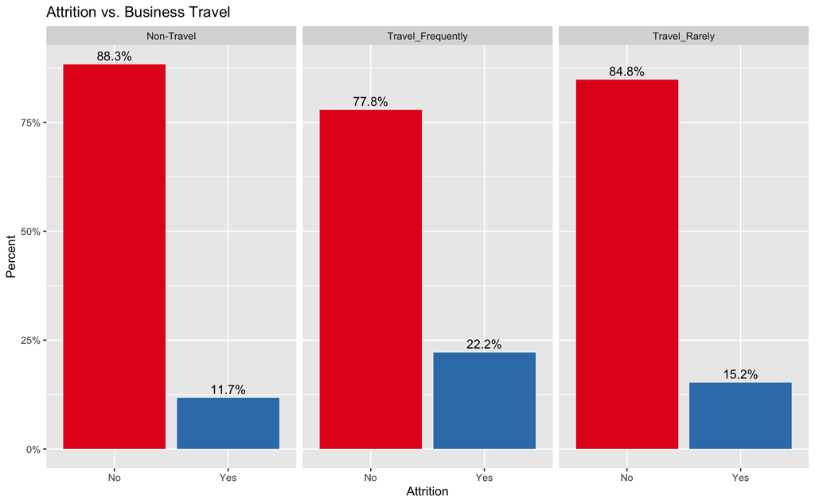

```r
# Attrition and Business Travel
ggplot(HR, aes(x = Attrition, group = BusinessTravel)) +
  geom_bar(aes(y = ..prop.., fill = factor(..x..)), stat = "count") +
  geom_text(aes(label = scales::percent(..prop..),
                y = ..prop..), stat = "count", vjust = -.5) +
  labs( y = "Percent", fill = "Attrition") +
  facet_grid(~BusinessTravel) +
  scale_y_continuous(labels = scales::percent) +
  ggtitle("Attrition vs. Business Travel") +
  scale_fill_brewer(palette="Set1") +
  theme(legend.position = 'none')
```

# Turnover Factor 1: Overtime Impacting Work/Life Balance

### Employees that worked overtime had a higher rate of attrition at 32% compared to those that didn’t work overtime at 10%.

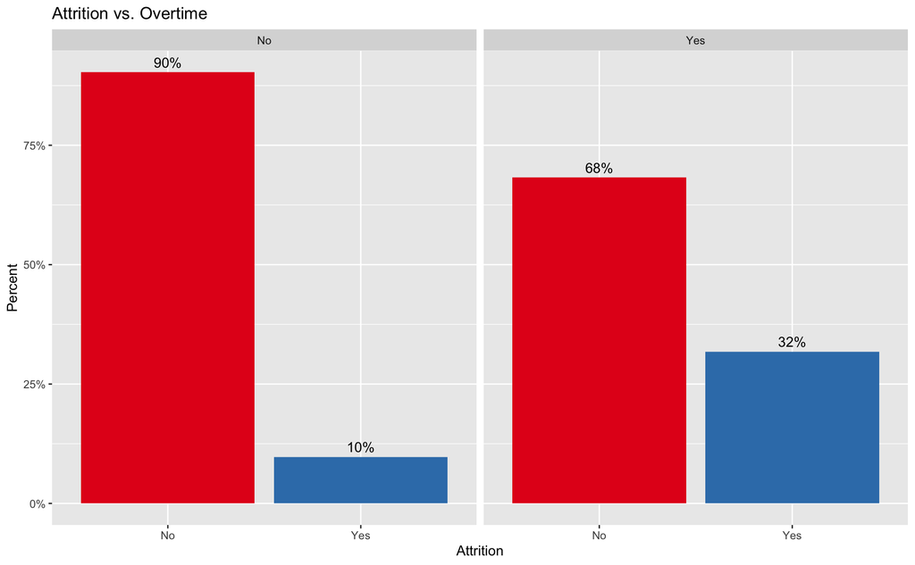

```r
# Attrition and Overtime
ggplot(HR, aes(x = Attrition, group = OverTime)) +
  geom_bar(aes(y = ..prop.., fill = factor(..x..)), stat = "count") +
  geom_text(aes(label = scales::percent(..prop..),
                y = ..prop..), stat = "count", vjust = -.5) +
  labs( y = "Percent", fill = "Attrition") +
  facet_grid(~OverTime) +
  scale_y_continuous(labels = scales::percent) +
  ggtitle("Attrition vs. Overtime") +
  scale_fill_brewer(palette="Set1") +
  theme(legend.position = 'none')
```

# Turnover Factor 2: Mean Monthly Income varies across different Job Levels Impacting Compensation

### These discrepancies in compensation could explain if attrition is higher in lower job levels compared to higher job levels as employees may leave to pursue higher compensation.

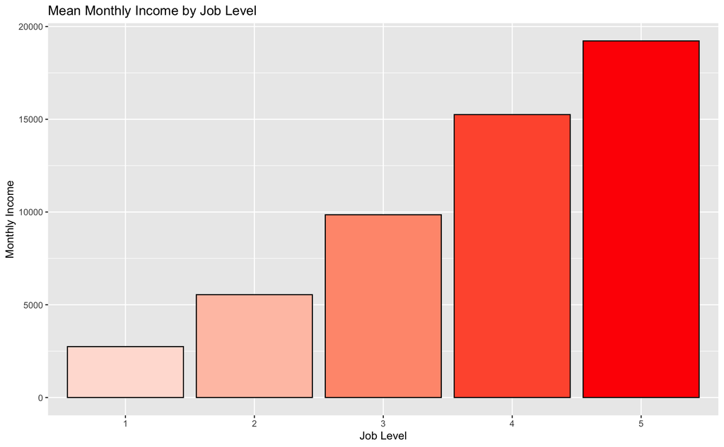

```r
# Job Level and Mean Monthly Income
data_histogram <- HR %>%
  mutate(JobLevel = factor(JobLevel)) %>%
  group_by(JobLevel) %>%
  summarize(Mean_MonthlyIncome = round(mean(MonthlyIncome), 2))

ggplot(data_histogram, aes(x = JobLevel, y = Mean_MonthlyIncome, fill = JobLevel)) +
  geom_bar(stat = "identity", color = "black", aes(fill = Mean_MonthlyIncome)) +
  scale_fill_gradient2(low='white', mid='snow', high='red') +
  ggtitle("Mean Monthly Income by Job Level") +
  xlab("Job Level") +
  ylab("Monthly Income") +
  theme(legend.position = 'none')
```

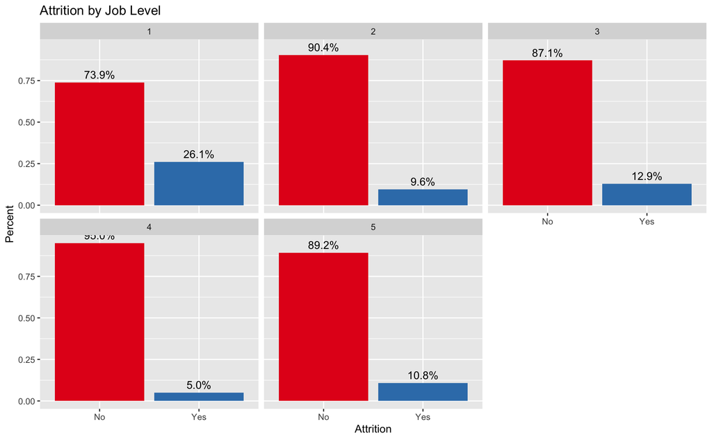

```r
# Attrition in different Job Levels
HR %>%
  ggplot(aes(x = Attrition, group = JobLevel)) +
  geom_bar(aes(y = ..prop.., fill = factor(..x..)),stat = "count") +
  geom_text(aes( label = scales::percent(..prop..),
                 y= ..prop.. ), stat = "count", vjust = -.5) +
  labs(y = "Percent", fill ="Attrition") +
  facet_wrap(~JobLevel) +
  ggtitle("Attrition by Job Level") +
  scale_fill_brewer(palette="Set1") +
  theme(legend.position = 'none')
```

# Turnover Factor 3: Certain Departments Are More Susceptible

### There are only three departments involved in this analysis which are Sales, HR, and Research & Development. Discovered that the Sales department has the highest attrition rate at 21% followed by Human Resources at 17%.

### These departments may experience higher attrition due to the nature of their departments where employees have to meet certain performance expectations which is critical to being successful in their roles. Therefore this and other job related factors could influence attrition.

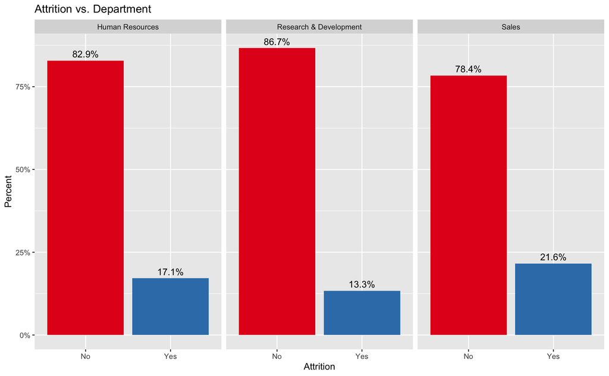

```r
# Attrition by Department
ggplot(HR, aes(x = Attrition, group = Department)) +
  geom_bar(aes(y = ..prop.., fill = factor(..x..)), stat = "count") +
  geom_text(aes(label = scales::percent(..prop..),
                y = ..prop..), stat = "count", vjust = -.5) +
  labs( y = "Percent", fill = "Attrition") +
  facet_grid(~Department) +
  scale_y_continuous(labels = scales::percent) +
  ggtitle("Attrition vs. Department") +
  scale_fill_brewer(palette="Set1") +
  theme(legend.position = 'none')
```

# Display Mean Monthly Income by Job Role

### Mean monthly income varies across job roles. Manager and Research Director have the highest monthly income at just over $15,000. Manufacturing Director and Healthcare Representative make around $7500. Laboratory Technician and Sales Representative make under $5000.

### Employees in management roles tend to have higher income. Employees in individual contributor roles tend to have lower income.

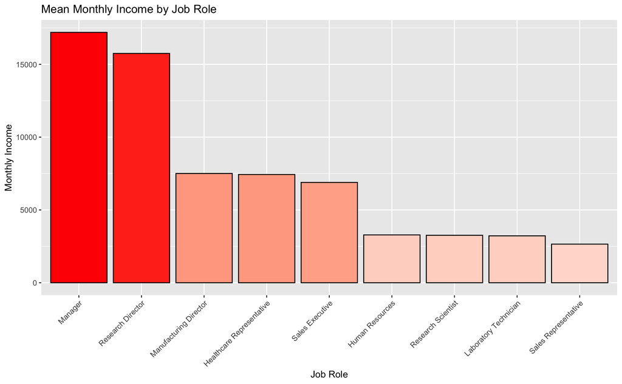

```r
# Job Specific Trends
# Mean Monthly Income by Job Role
HR$JobRole <- fct_reorder(HR$JobRole, HR$MonthlyIncome, 'mean', .desc = TRUE)
HR %>%
  group_by(JobRole) %>%
  summarize(Mean_MonthlyIncome = mean(MonthlyIncome)) %>%
  ggplot(aes(x = JobRole, y = Mean_MonthlyIncome)) +
  geom_bar(stat = "identity", color = "black", aes(fill = Mean_MonthlyIncome)) +
  scale_fill_gradient2(low='white', mid='snow', high='red') +
  ggtitle("Mean Monthly Income by Job Role") +
  xlab("Job Role") +
  ylab("Monthly Income") +
  theme(axis.text.x = element_text(angle = 45, hjust = 1)) +
  theme(legend.position = 'none')
```

# Attrition Comparison by Gender based on Job Satisfaction

### Both Female and Male employees that stay have the same median satisfaction score at 3. However, for Female employees that leave the satisfaction score is lower at 2 compared to Male at 3.

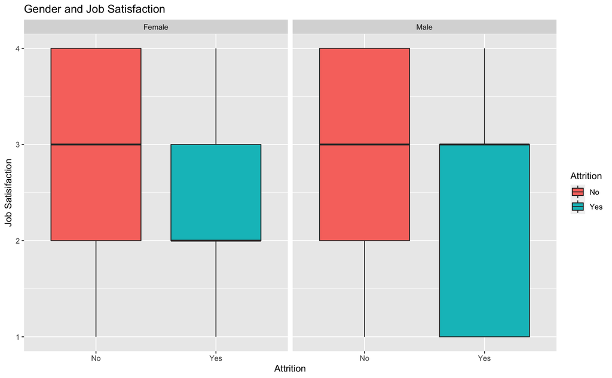

```r
# Job Specific Trends
# Boxplot of Gender Satisfaction
ggplot(data = HR) +
  geom_boxplot(aes(x = Attrition, y = JobSatisfaction, fill = Attrition)) +
  ggtitle("Gender and Job Satisfaction") +
  facet_wrap(~Gender) +
  ylab("Job Satisifaction")
```

```r
# Female Mean Monthly Income at 6696.26
HR %>%
  filter(Gender == "Female") %>%
  summarize(Mean_MonthlyIncome = mean(MonthlyIncome))
```

```
##   Mean_MonthlyIncome
## 1            6696.26
```

```r
# Male Mean Monthly Income 6180.337
HR %>%
  filter(Gender == "Male") %>%
  summarize(Mean_MonthlyIncome = mean(MonthlyIncome))
```

```
##   Mean_MonthlyIncome
## 1           6180.337
```

# Classifying Likelihood of Attrition

### The KNN classification and Naive Bayes models below will determine the probability of whether an employee is likely to stay or leave the company given their Monthly Income and Job Level. Will also explore other combinations like Monthly Income and Age.

Finally there is a scatterplot for a visual check on the relationship.

The following code also compares the KNN model to Naive Bayes to determine which model performed better.

Please note, upsampling was used to balance the dataset to ensure the training and test sets could draw from an equal distribution of data, especially with the Attrition variable.

```r
# KNN Classification before upsampling
# Use Monthly Income and Job Level to predict Attrition

# Change Attrition to factor
HR$Attrition = as.factor(HR$Attrition)

# KNN of unknown Attrition with Monthly Income of 4403 and Job Level of 2
df = data.frame(MonthlyIncome = 4403 , JobLevel = 2 )
knn(HR[,c(16,20)], df, HR$Attrition, k = 5, prob = TRUE)
```

```
## [1] Yes
## attr(,"prob")
## [1] 0.8
## Levels: No Yes
```

```r
knn(HR[,c(16,20)], df, HR$Attrition, k = 15, prob = TRUE)
```

```
## [1] Yes
## attr(,"prob")
## [1] 0.5333333
## Levels: No Yes
```

```r
knn(HR[,c(16,20)], df, HR$Attrition, k = 30, prob = TRUE)
```

```
## [1] No
## attr(,"prob")
## [1] 0.5483871
## Levels: No Yes
```

```r
# KNN of unknown Attrition with Monthly Income of 19626 and Job Level of 5
df1 = data.frame(MonthlyIncome = 9362 , JobLevel = 5 )
knn(HR[,c(16,20)], df1, HR$Attrition, k = 5, prob = TRUE)
```

[output not shown]

```r
knn(HR[,c(16,20)], df1, HR$Attrition, k = 15, prob = TRUE)
```

```
## [1] Yes
## attr(,"prob")
## [1] 0.5333333
## Levels: No Yes
```

```r
knn(HR[,c(16,20)], df1, HR$Attrition, k = 30, prob = TRUE)
```

```
## [1] No
## attr(,"prob")
## [1] 0.5483871
## Levels: No Yes
```

```r
# Create training and test sets
trainInd = sample(seq(1,870,1), .7*870)
train = HR[trainInd,]
test = HR[-trainInd,]

# Note, before upsampling specificity is well below 60% target
# Testing with k = 5
classifications = knn(train[,c(16,20)],test[,c(16,20)],train$Attrition, prob = TRUE, k = 5)
confusionMatrix(table(classifications,test$Attrition))
```

```
## Confusion Matrix and Statistics
##
##
## classifications  No Yes
##             No  219  37
##             Yes   3   2
##
##                Accuracy : 0.8467
##                  95% CI : (0.7972, 0.8882)
##     No Information Rate : 0.8506
##     P-Value [Acc > NIR] : 0.61
##
##                   Kappa : 0.059
##
##  Mcnemar's Test P-Value : 1.811e-07
##
##             Sensitivity : 0.98649
##             Specificity : 0.05128
##          Pos Pred Value : 0.85547
##          Neg Pred Value : 0.40000
##              Prevalence : 0.85057
##          Detection Rate : 0.83908
##    Detection Prevalence : 0.98084
##       Balanced Accuracy : 0.51888
##
##        'Positive' Class : No
##
```

```r
# Testing with k = 15
classifications = knn(train[,c(16,20)],test[,c(16,20)],train$Attrition, prob = TRUE, k = 15)
confusionMatrix(table(classifications,test$Attrition))
```

```
## Confusion Matrix and Statistics
##
##
## classifications  No Yes
##             No  222  39
##             Yes   0   0
##
##                Accuracy : 0.8506
##                  95% CI : (0.8014, 0.8915)
##     No Information Rate : 0.8506
##     P-Value [Acc > NIR] : 0.5426
##
##                   Kappa : 0
##
##  Mcnemar's Test P-Value : 1.166e-09
##
##             Sensitivity : 1.0000
##             Specificity : 0.0000
##          Pos Pred Value : 0.8506
##          Neg Pred Value :    NaN
##              Prevalence : 0.8506
##          Detection Rate : 0.8506
##    Detection Prevalence : 1.0000
##       Balanced Accuracy : 0.5000
##
##        'Positive' Class : No
##
```

```r
# Testing with k = 30
classifications = knn(train[,c(16,20)],test[,c(16,20)],train$Attrition, prob = TRUE, k = 30)
confusionMatrix(table(classifications,test$Attrition))
```

```
## Confusion Matrix and Statistics
##
##
## classifications  No Yes
##             No  222  39
##             Yes   0   0
##
##                Accuracy : 0.8506
##                  95% CI : (0.8014, 0.8915)
##     No Information Rate : 0.8506
##     P-Value [Acc > NIR] : 0.5426
##
##                   Kappa : 0
##
##  Mcnemar's Test P-Value : 1.166e-09
##
##             Sensitivity : 1.0000
##             Specificity : 0.0000
##          Pos Pred Value : 0.8506
##          Neg Pred Value :    NaN
##              Prevalence : 0.8506
##          Detection Rate : 0.8506
##    Detection Prevalence : 1.0000
##       Balanced Accuracy : 0.5000
##
##        'Positive' Class : No
##
```

```r
# Naive Bayes before upsampling
# Use Monthly Income and Job Level to predict Attrition

# Naive Bayes with Monthly Income and Job Level
model = naiveBayes(HR[,c(16,20)],HR$Attrition)
predict(model,data.frame(MonthlyIncome = 4403, JobLevel = 2))
```

```
## [1] No
## Levels: No Yes
```

```r
predict(model,data.frame(MonthlyIncome = 4403, JobLevel = 2), type = "raw")
```

```
##             No       Yes
## [1,] 0.7813778 0.2186222
```

```r
# Split data into training and test sets
set.seed(20)
trainIndices = sample(seq(1,870,1), .7*870)
trainHR = HR[trainIndices,]
testHR = HR[-trainIndices,]

# NB Model based on training set using Monthly Income and Job Level
nbmodel = naiveBayes(trainHR[,c(16,20)],trainHR$Attrition)
table(predict(nbmodel,testHR[,c(16,20)]),testHR$Attrition)
```

```
##
##        No Yes
##   No  225  36
##   Yes   0   0
```

```r
CM = confusionMatrix(table(predict(nbmodel,testHR[,c(16,20)]),testHR$Attrition))
CM
```

```
## Confusion Matrix and Statistics
##
##
##        No Yes
##   No  225  36
##   Yes   0   0
##
##                Accuracy : 0.8621
##                  95% CI : (0.8142, 0.9015)
##     No Information Rate : 0.8621
##     P-Value [Acc > NIR] : 0.5443
##
##                   Kappa : 0
##
##  Mcnemar's Test P-Value : 5.433e-09
##
##             Sensitivity : 1.0000
##             Specificity : 0.0000
##          Pos Pred Value : 0.8621
##          Neg Pred Value :    NaN
##              Prevalence : 0.8621
##          Detection Rate : 0.8621
##    Detection Prevalence : 1.0000
##       Balanced Accuracy : 0.5000
##
##        'Positive' Class : No
##
```

```r
# KNN Classification after upsampling
# Upsampling to make sure equal number of Yes/No
HR1.up = upSample(HR[,-3], HR$Attrition, yname = "Attrition")
str(HR1.up)
```

```
## 'data.frame':    1460 obs. of  36 variables:
##  $ ID                      : int  1 2 3 4 5 6 7 8 9 10 ...
##  $ Age                     : int  32 40 35 32 24 27 41 37 34 34 ...
##  $ BusinessTravel          : chr  "Travel_Rarely" "Travel_Rarely" "Travel_Frequently" "Travel_Rarely" ...
##  $ DailyRate               : int  117 1308 200 801 567 294 1283 309 1333 653 ...
##  $ Department              : chr  "Sales" "Research & Development" "Research & Development" "Sales" ...
##  $ DistanceFromHome        : int  13 14 18 1 2 10 5 10 10 10 ...
##  $ Education               : int  4 3 2 4 1 2 5 4 4 4 ...
##  $ EducationField          : chr  "Life Sciences" "Medical" "Life Sciences" "Marketing" ...
##  $ EmployeeCount           : int  1 1 1 1 1 1 1 1 1 1 ...
##  $ EmployeeNumber          : int  859 1128 1412 2016 1646 733 1448 1105 1055 1597 ...
##  $ EnvironmentSatisfaction : int  2 3 3 3 1 4 2 4 3 4 ...
##  $ Gender                  : chr  "Male" "Male" "Male" "Female" ...
##  $ HourlyRate              : int  73 44 60 48 32 32 90 88 87 92 ...
##  $ JobInvolvement          : int  3 2 3 3 3 3 4 2 3 2 ...
```

[output cut: 22 more lines]

```r
table(HR1.up$Attrition)
```

```
##
##  No Yes
## 730 730
```

```r
# Use Monthly Income and Job Level to predict Attrition
# Change Attrition to factor
HR1.up$Attrition = as.factor(HR1.up$Attrition)

# KNN of unknown Attrition with Monthly Income of 4403 and Job Level of 2
df2 = data.frame(MonthlyIncome = 4403 , JobLevel = 2 )
knn(HR1.up[,c(15,19)], df2, HR1.up$Attrition, k = 5, prob = TRUE)
```

```
## [1] Yes
## attr(,"prob")
## [1] 1
## Levels: No Yes
```

```r
knn(HR1.up[,c(15,19)], df2, HR1.up$Attrition, k = 15, prob = TRUE)
```

```
## [1] Yes
## attr(,"prob")
## [1] 1
## Levels: No Yes
```

```r
knn(HR1.up[,c(15,19)], df2, HR1.up$Attrition, k = 30, prob = TRUE)
```

```
## [1] Yes
## attr(,"prob")
## [1] 0.8787879
## Levels: No Yes
```

```r
# KNN of unknown Attrition with Monthly Income of 19626 and Age of 40
df3 = data.frame(MonthlyIncome = 19626 , Age = 40 )
knn(HR1.up[,c(2,19)], df3, HR1.up$Attrition, k = 5, prob = TRUE)
```

```
## [1] Yes
## attr(,"prob")
## [1] 1
## Levels: No Yes
```

```r
knn(HR1.up[,c(2,19)], df3, HR1.up$Attrition, k = 15, prob = TRUE)
```

```
## [1] Yes
## attr(,"prob")
## [1] 0.875
## Levels: No Yes
```

```r
knn(HR1.up[,c(2,19)], df3, HR1.up$Attrition, k = 30, prob = TRUE)
```

```
## [1] Yes
## attr(,"prob")
## [1] 0.8787879
## Levels: No Yes
```

```r
# Create training and test sets using upsampled data
trainIndHR1 = sample(seq(1,1460,1), .7*1460)
trainHR1 = HR1.up[trainIndHR1,]
testHR1 = HR1.up[-trainIndHR1,]


# Monthly Income and Job Level
# Testing with k = 5
classifications = knn(trainHR1[,c(15,19)],testHR1[,c(15,19)],trainHR1$Attrition, prob = TRUE, k = 5)
confusionMatrix(table(classifications,testHR1$Attrition))
```

```
## Confusion Matrix and Statistics
##
##
## classifications  No Yes
##             No  101  26
##             Yes 122 190
##
##                Accuracy : 0.6629
##                  95% CI : (0.6165, 0.707)
##     No Information Rate : 0.508
##     P-Value [Acc > NIR] : 3.853e-11
##
##                   Kappa : 0.3302
##
##  Mcnemar's Test P-Value : 5.767e-15
##
##             Sensitivity : 0.4529
##             Specificity : 0.8796
##          Pos Pred Value : 0.7953
##          Neg Pred Value : 0.6090
##              Prevalence : 0.5080
##          Detection Rate : 0.2301
##    Detection Prevalence : 0.2893
##       Balanced Accuracy : 0.6663
##
##        'Positive' Class : No
##
```

```r
# Testing with k = 15
classifications = knn(trainHR1[,c(15,19)],testHR1[,c(15,19)],trainHR1$Attrition, prob = TRUE, k = 15)
confusionMatrix(table(classifications,testHR1$Attrition))
```

```
## Confusion Matrix and Statistics
##
##
## classifications  No Yes
##             No  113  48
##             Yes 110 168
##
##                Accuracy : 0.6401
##                  95% CI : (0.5932, 0.6851)
##     No Information Rate : 0.508
##     P-Value [Acc > NIR] : 1.618e-08
##
##                   Kappa : 0.2832
##
##  Mcnemar's Test P-Value : 1.217e-06
##
##             Sensitivity : 0.5067
##             Specificity : 0.7778
##          Pos Pred Value : 0.7019
##          Neg Pred Value : 0.6043
##              Prevalence : 0.5080
##          Detection Rate : 0.2574
##    Detection Prevalence : 0.3667
##       Balanced Accuracy : 0.6423
##
##        'Positive' Class : No
##
```

```r
# Testing with k = 30
classifications = knn(trainHR1[,c(15,19)],testHR1[,c(15,19)],trainHR1$Attrition, prob = TRUE, k = 30)
confusionMatrix(table(classifications,testHR1$Attrition))
```

```
## Confusion Matrix and Statistics
##
##
## classifications  No Yes
##             No  128  76
##             Yes  95 140
##
##                Accuracy : 0.6105
##                  95% CI : (0.5631, 0.6564)
##     No Information Rate : 0.508
##     P-Value [Acc > NIR] : 9.921e-06
##
##                   Kappa : 0.2218
##
##  Mcnemar's Test P-Value : 0.1687
##
##             Sensitivity : 0.5740
##             Specificity : 0.6481
##          Pos Pred Value : 0.6275
##          Neg Pred Value : 0.5957
##              Prevalence : 0.5080
##          Detection Rate : 0.2916
##    Detection Prevalence : 0.4647
##       Balanced Accuracy : 0.6111
##
##        'Positive' Class : No
##
```

```r
# Testing with k = 31
classifications = knn(trainHR1[,c(15,19)],testHR1[,c(15,19)],trainHR1$Attrition, prob = TRUE, k = 31)
confusionMatrix(table(classifications,testHR1$Attrition))
```

```
## Confusion Matrix and Statistics
##
##
## classifications  No Yes
##             No  130  75
##             Yes  93 141
##
##                Accuracy : 0.6173
##                  95% CI : (0.57, 0.663)
##     No Information Rate : 0.508
##     P-Value [Acc > NIR] : 2.595e-06
##
##                   Kappa : 0.2354
##
##  Mcnemar's Test P-Value : 0.1897
##
##             Sensitivity : 0.5830
##             Specificity : 0.6528
##          Pos Pred Value : 0.6341
##          Neg Pred Value : 0.6026
##              Prevalence : 0.5080
##          Detection Rate : 0.2961
##    Detection Prevalence : 0.4670
##       Balanced Accuracy : 0.6179
##
##        'Positive' Class : No
##
```

```r
# Monthly Income and Age
# Testing with k = 5
classifications = knn(trainHR1[,c(2,19)],testHR1[,c(2,19)],trainHR1$Attrition, prob = TRUE, k = 5)
confusionMatrix(table(classifications,testHR1$Attrition))
```

```
## Confusion Matrix and Statistics
##
##
## classifications  No Yes
##             No   98  37
##             Yes 125 179
##
##                Accuracy : 0.631
##                  95% CI : (0.5839, 0.6762)
##     No Information Rate : 0.508
##     P-Value [Acc > NIR] : 1.381e-07
##
##                   Kappa : 0.2665
##
##  Mcnemar's Test P-Value : 8.180e-12
##
##             Sensitivity : 0.4395
##             Specificity : 0.8287
##          Pos Pred Value : 0.7259
##          Neg Pred Value : 0.5888
##              Prevalence : 0.5080
##          Detection Rate : 0.2232
##    Detection Prevalence : 0.3075
##       Balanced Accuracy : 0.6341
##
##        'Positive' Class : No
##
```

```r
# Testing with k = 15
classifications = knn(trainHR1[,c(2,19)],testHR1[,c(2,19)],trainHR1$Attrition, prob = TRUE, k = 15)
confusionMatrix(table(classifications,testHR1$Attrition))
```

```
## Confusion Matrix and Statistics
##
##
## classifications  No Yes
##             No  115  47
##             Yes 108 169
##
##                Accuracy : 0.6469
##                  95% CI : (0.6002, 0.6916)
##     No Information Rate : 0.508
##     P-Value [Acc > NIR] : 2.928e-09
##
##                   Kappa : 0.2968
##
##  Mcnemar's Test P-Value : 1.441e-06
##
##             Sensitivity : 0.5157
##             Specificity : 0.7824
##          Pos Pred Value : 0.7099
##          Neg Pred Value : 0.6101
##              Prevalence : 0.5080
##          Detection Rate : 0.2620
##    Detection Prevalence : 0.3690
##       Balanced Accuracy : 0.6491
##
##        'Positive' Class : No
##
```

```r
# Testing with k = 30
classifications = knn(trainHR1[,c(2,19)],testHR1[,c(2,19)],trainHR1$Attrition, prob = TRUE, k = 30)
confusionMatrix(table(classifications,testHR1$Attrition))
```

```
## Confusion Matrix and Statistics
##
##
## classifications  No Yes
##             No  132  74
##             Yes  91 142
##
##                Accuracy : 0.6241
##                  95% CI : (0.577, 0.6696)
##     No Information Rate : 0.508
##     P-Value [Acc > NIR] : 6.246e-07
##
##                   Kappa : 0.249
##
##  Mcnemar's Test P-Value : 0.2129
##
##             Sensitivity : 0.5919
##             Specificity : 0.6574
##          Pos Pred Value : 0.6408
##          Neg Pred Value : 0.6094
##              Prevalence : 0.5080
##          Detection Rate : 0.3007
##    Detection Prevalence : 0.4692
##       Balanced Accuracy : 0.6247
##
##        'Positive' Class : No
##
```

```r
# Testing with k = 31
classifications = knn(trainHR1[,c(2,19)],testHR1[,c(2,19)],trainHR1$Attrition, prob = TRUE, k = 31)
confusionMatrix(table(classifications,testHR1$Attrition))
```

```
## Confusion Matrix and Statistics
##
##
## classifications  No Yes
##             No  133  75
##             Yes  90 141
##
##                Accuracy : 0.6241
##                  95% CI : (0.577, 0.6696)
##     No Information Rate : 0.508
##     P-Value [Acc > NIR] : 6.246e-07
##
##                   Kappa : 0.2489
##
##  Mcnemar's Test P-Value : 0.2758
##
##             Sensitivity : 0.5964
##             Specificity : 0.6528
##          Pos Pred Value : 0.6394
##          Neg Pred Value : 0.6104
##              Prevalence : 0.5080
##          Detection Rate : 0.3030
##    Detection Prevalence : 0.4738
##       Balanced Accuracy : 0.6246
##
##        'Positive' Class : No
##
```

```r
# Naive Bayes after upsampling

# NB Model based on training set using Monthly Income and Job Level
nbmodel1 = naiveBayes(trainHR1[,c(15,19)],trainHR1$Attrition)
table(predict(nbmodel1,testHR1[,c(15,19)]),testHR1$Attrition)
```

```
##
##        No Yes
##   No   73  43
##   Yes 150 173
```

```r
CM1 = confusionMatrix(table(predict(nbmodel1,testHR1[,c(15,19)]),testHR1$Attrition))
CM1
```

```
## Confusion Matrix and Statistics
##
##
##        No Yes
##   No   73  43
##   Yes 150 173
##
##                Accuracy : 0.5604
##                  95% CI : (0.5125, 0.6074)
##     No Information Rate : 0.508
##     P-Value [Acc > NIR] : 0.01576
##
##                   Kappa : 0.1273
##
##  Mcnemar's Test P-Value : 2.347e-14
##
##             Sensitivity : 0.3274
##             Specificity : 0.8009
##          Pos Pred Value : 0.6293
##          Neg Pred Value : 0.5356
##              Prevalence : 0.5080
##          Detection Rate : 0.1663
##    Detection Prevalence : 0.2642
##       Balanced Accuracy : 0.5641
##
##        'Positive' Class : No
##
```

### The Naive Bayes model below provides the best outcome in indentifying Attrition

- Achieved Sensitivity and Specificity at 60% or above.

```r
# NB Model based on training set using Monthly Income and Age
nbmodel1 = naiveBayes(trainHR1[,c(2,20)],trainHR1$Attrition)
table(predict(nbmodel1,testHR1[,c(2,20)]),testHR1$Attrition)
```

```
##
##        No Yes
##   No  134  70
##   Yes  89 146
```

```r
CM1 = confusionMatrix(table(predict(nbmodel1,testHR1[,c(2,20)]),testHR1$Attrition))
CM1
```

```
## Confusion Matrix and Statistics
##
##
##        No Yes
##   No  134  70
##   Yes  89 146
##
##                Accuracy : 0.6378
##                  95% CI : (0.5909, 0.6829)
##     No Information Rate : 0.508
##     P-Value [Acc > NIR] : 2.806e-08
##
##                   Kappa : 0.2764
##
##  Mcnemar's Test P-Value : 0.1534
##
##             Sensitivity : 0.6009
##             Specificity : 0.6759
##          Pos Pred Value : 0.6569
##          Neg Pred Value : 0.6213
##              Prevalence : 0.5080
##          Detection Rate : 0.3052
##    Detection Prevalence : 0.4647
##       Balanced Accuracy : 0.6384
##
##        'Positive' Class : No
##
```

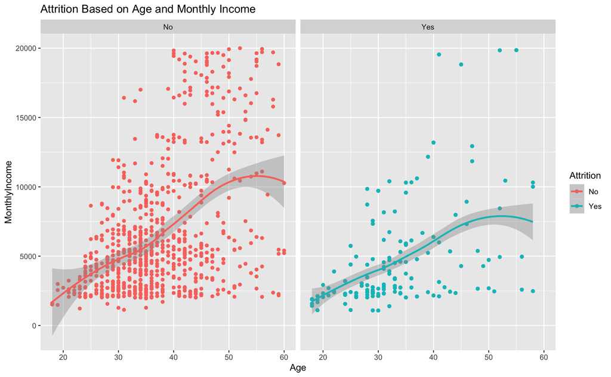

```r
# Scatterplot displaying likelihood of attrition based on Age and Monthly Income
ggplot(data = HR1.up) +
  geom_point(mapping = aes(x = Age, y = MonthlyIncome, color = Attrition)) +
  geom_smooth(aes(x = Age, y = MonthlyIncome, color = Attrition)) +
  facet_wrap(~ Attrition) +
  ggtitle("Attrition Based on Age and Monthly Income")
```

# RMSE of Final Model

```r
# Dataframe with Monthly Income and Total Working Years
HR2 = HR1.up %>%
  select(TotalWorkingYears, MonthlyIncome)

# Load the data
data("HR2", package = "MASS")
# Inspect the data

sample_n(HR2, 3)
```

```
##   TotalWorkingYears MonthlyIncome
## 1                 0          1904
## 2                10          2206
## 3                22         10739
```

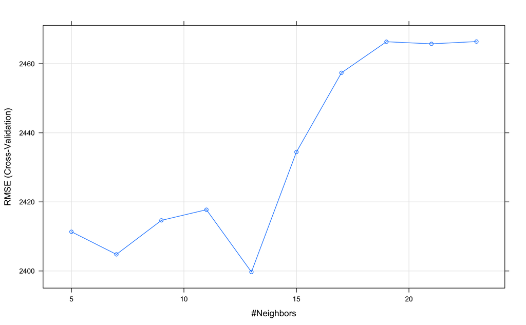

```r
# Split the data into training and test set
set.seed(123)
training.samples <- HR2$MonthlyIncome %>%
  createDataPartition(p = 0.7, list = FALSE)
train.data  <- HR2[training.samples, ]
test.data <- HR2[-training.samples, ]

# Fit the model on the training set
set.seed(123)
model <- train(
  MonthlyIncome~., data = train.data, method = "knn",
  trControl = trainControl("cv", number = 10),
  preProcess = c("center","scale"),
  tuneLength = 10
)
# Plot model error RMSE vs different values of k
plot(model)
```

```r
# Best tuning parameter k that minimize the RMSE
model$bestTune
```

```
##    k
## 5 13
```

```r
# Make predictions on the test data
predictions <- model %>% predict(test.data)
head(predictions)
```

```
## [1] 4055.152 4201.832 4055.152 2141.841 5957.051 4201.832
```

```r
# Compute the prediction error RMSE
RMSE(predictions, test.data$MonthlyIncome)
```

```
## [1] 2332.991
```

```r
RMSE(predictions, train.data$MonthlyIncome)
```

```
## [1] 5610.522
```

# Linear Regression

### The estimated mean monthly income for an employee’s age of 30 years old is $4710 per month. We are 95% confident that the mean monthly income is between $4266 and $5154 per month.

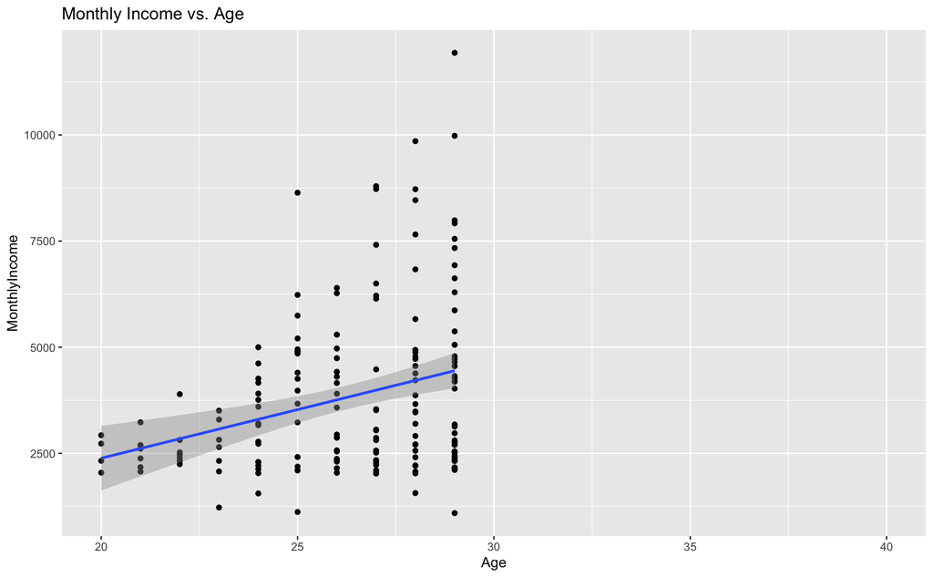

```r
# Linear Regression
HR %>%
  filter(Age < 30) %>%
  ggplot(aes(x = Age, y = MonthlyIncome)) +
  geom_point() +
  ggtitle("Monthly Income vs. Age") +
  geom_smooth(method = "lm") +
  xlim(20,40)
```

```r
HR3 = HR %>%
  filter(Age < 30)
fit = lm(MonthlyIncome ~ Age, HR3)
summary(fit)
```

```
##
## Call:
## lm(formula = MonthlyIncome ~ Age, data = HR3)
##
## Residuals:
##    Min     1Q Median     3Q    Max
##  -3378  -1338   -276    674   7466
##
## Coefficients:
##             Estimate Std. Error t value Pr(>|t|)
## (Intercept) -2521.16    1103.84  -2.284   0.0235 *
## Age           241.05      42.59   5.660 5.77e-08 ***
## ---
## Signif. codes:  0 '***' 0.001 '**' 0.01 '*' 0.05 '.' 0.1 ' ' 1
##
## Residual standard error: 1804 on 183 degrees of freedom
## Multiple R-squared:  0.149,  Adjusted R-squared:  0.1443
## F-statistic: 32.03 on 1 and 183 DF,  p-value: 5.774e-08
```

```r
confint(fit)
```

```
##                  2.5 %    97.5 %
## (Intercept) -4699.0538 -343.2568
## Age           157.0139  325.0776
```

```r
Employee_Age = data.frame(Age = 30)
predict(fit, newdata = Employee_Age, interval = "confidence")
```

```
##        fit      lwr      upr
## 1 4710.217 4266.078 5154.356
```

# Conclusion:

### Based on these insights have the following recommendations that Frito-Lay can explore in further detail:

1. Companies should offer flexible work options for employees that left companies due to business travel or overtime
2. Since younger employees are more likely to leave companies early in their career for other opportunities or better compensation, companies should offer higher salaries in entry level roles
3. Companies should assess job satisfaction of department/roles in more detail to understand if conditions or performance expectations can be improved to lesson attrition

### Reference Youtube Presentation for detailed overview:

- https://youtu.be/ms2W7HdwB4o